# Analysis of Bikeshare Data in 2018: User Type, Trip Duration, and Usage Patterns.

Muhammad Enrizky Brillian_1009713712

2023-04-08

# 1. Merging Datasets from multiple CSVs

```r
# loading libraries
library(tidyverse)
library(dplyr)
#Setting the working Directory
setwd("~/STAA57_Project")
# Create empty data frame
bikeshare_data <- data.frame()
# Loop through all CSV files in folder
for (file in list.files(pattern=".csv")) {
  temp_data <- read.csv(file, header=TRUE)  # Read in CSV file
  bikeshare_data <- rbind(bikeshare_data, temp_data)  # Bind data to the df
  rm(temp_data)  # Remove original data to free up memory
}
```

# 2. Description of the Dataset

```r
names(bikeshare_data)
```

```
## [1] "trip_id"               "trip_duration_seconds" "from_station_id"
## [4] "trip_start_time"       "from_station_name"     "trip_stop_time"
## [7] "to_station_id"         "to_station_name"       "user_type"
```

# 3. The Background of the Data

The bikeshare data for 2018 was collected by the City of Toronto, specifically by the Transportation Services division. The data was collected in the context of a bikeshare program called Bike Share Toronto, which is a public bicycle sharing system in Toronto, Canada. Bike Share Toronto provides access to bicycles at various stations throughout the city, allowing users to rent a bike for short trips and return it to any station within the system. The data collected includes information about bike trips, such as trip duration, start and end station, and user type, and other variables.This data is publicly available through the City of Toronto’s Open Data portal for research and analysis purposes.

**The dataset can be used for analysis and insights into the usage patterns and trends of the bikeshare program in Toronto during the year 2018. It is typically used by researchers, policymakers, and urban planners to analyze bike usage patterns, evaluate the effectiveness of the bikeshare program, and inform transportation planning and policy decisions. Overall, the bikeshare data for 2018 is a valuable resource for investigating bike usage patterns, user behavior, and system performance in Toronto, and can contribute to evidence-based decision making in transportation planning and policy.**

# 4. What is the overall research question?

As researchers, our overall research question is to investigate the usage patterns and trends of bikeshare data in Toronto for the year 2018. We aim to analyze various variables, such as trip duration, trip start time, user type, and station information, to gain insights into how the bikeshare system was utilized by different user groups, and to identify any patterns or trends that may emerge from the data. Specifically, our research question is:

1. What are the summary statistics for trip duration by user type, and how do they compare?
2. How does the total number of trips taken by each user type vary by month?
3. What are the top 10 most popular starting stations for bike rides in the dataset?
4. How many trips lasted 30 minutes or more, and how many lasted 45 minutes or more, for each user type?
5. What is the trend of total trips by hour of day, and how does it relate to peak usage times?
6. How does monthly trip volume vary by user type, and what is the overall trend over the year?

# 5. Tables

## 5.1 Trip Duration (in Seconds) Summary By User Type

Summary of Trip Duration (in seconds) by User Type

| user_type | Number_Trips | Average_duration | Median_duration | Min_duration | Max_duration |
| --- | --- | --- | --- | --- | --- |
| Annual Member | 1572980 | 725.0167 | 600 | 60 | 55077 |
| Casual Member | 349975 | 2032.4958 | 1220 | 60 | 54971 |

From the table, we can see that the “Annual Member” user type has a significantly larger number of trips (1,572,980) than the “Casual Member” user type (349,975). However, the “Casual Member” user type has a higher average trip duration (2,032.4958 seconds) compared to the “Annual Member” user type (725.0167 seconds). The median duration for both user types is lower than the average, which indicates that there are some trips with much higher durations, skewing the average upwards.

## 5.2 Table of Total Trips by Month for each user type

Total Trips by Month for each user type

| Month | Annual Member | Casual Member |
| --- | --- | --- |
| Jan | 42469 | 1390 |
| Feb | 47276 | 2455 |
| Mar | 78564 | 6405 |
| Apr | 82194 | 12589 |
| May | 160989 | 51761 |
| Jun | 186463 | 64374 |
| Jul | 215835 | 70481 |
| Aug | 209770 | 71449 |
| Sep | 207789 | 47212 |
| Oct | 160326 | 15553 |
| Nov | 100675 | 3612 |
| Dec | 80630 | 2694 |

The Table of Total Trips by Month for each user type displays the total number of trips taken by annual members and casual members for each month of the year. For example, in January, there were 42,469 trips taken by annual members and 1,390 trips taken by casual members. In February, there were 47,276 trips taken by annual members and 2,455 trips taken by casual members. This continues for each month of the year, showing the total number of trips taken by each user type.

This table can provide insights into how usage of the bike share service varies by month and by user type. For example, it appears that usage by both annual and casual members increases during the warmer months, as the number of trips taken by both groups is much higher in the summer months (June through August) compared to the winter months (December through February). It also appears that annual members take many more trips overall than casual members.

## 5.3 The Top 10 Most Popular Starting Stations

Top 10 Most Popular Starting stations

| Starting Station | num_trips |
| --- | --- |
| York St / Queens Quay W | 24017 |
| Bay St / Queens Quay W (Ferry Terminal) | 22743 |
| Union Station | 19869 |
| Bay St / Wellesley St W | 19184 |
| Sherbourne St / Wellesley St E | 19131 |
| Front St W / Blue Jays Way | 17282 |
| Princess St / Adelaide St E | 17089 |
| Dundas St W / Yonge St | 17054 |
| Bay St / College St (East Side) | 16965 |
| Bathurst St/Queens Quay(Billy Bishop Airport) | 16794 |

This table shows the top 10 most popular starting stations for bike rides in the given dataset. It lists the names of the stations under the column “Starting Station” and the corresponding number of trips that started from that station under the column “num_trips”.

The table is sorted in descending order based on the number of trips, so the station with the highest number of trips is listed first. According to the table, the most popular starting station is “York St / Queens Quay W” with 24,017 trips, followed by “Bay St / Queens Quay W (Ferry Terminal)” with 22,743 trips, and “Union Station” with 19,869 trips.

This table can be useful for bike-sharing companies or city officials to identify the most popular locations for bike rides and allocate their resources accordingly, such as providing more bikes or improving bike infrastructure in those areas.

## 5.4 Trip duration More than 30 minutes and More than 45 minutes

Trip Duration more than 30 minutes and 45 minutes.

| user_type | >= 30 mins | >= 45 mins |
| --- | --- | --- |
| Annual Member | 32647 | 10364 |
| Casual Member | 87792 | 51791 |

The table “Trip Duration more than 30 minutes and 45 minutes” shows the number of trips taken by each user type (Annual Member and Casual Member) that lasted 30 minutes or more and 45 minutes or more, respectively.

For Annual Members, there were 32,647 trips that lasted 30 minutes or more, and 10,364 trips that lasted 45 minutes or more. For Casual Members, there were 87,792 trips that lasted 30 minutes or more, and 51,791 trips that lasted 45 minutes or more.

This information could be useful for analyzing the usage patterns of different user types and identifying potential areas for improvement in the bike sharing system. For example, if a significant number of casual users are taking longer trips, the bike sharing company could consider offering different pricing plans or incentives to encourage shorter trips and more frequent use. Additionally, the data could help inform decisions about bike station placement and bike fleet size based on usage patterns.

# 6. Graphs

## 6.1 Line Chart of Total Trips by Hour

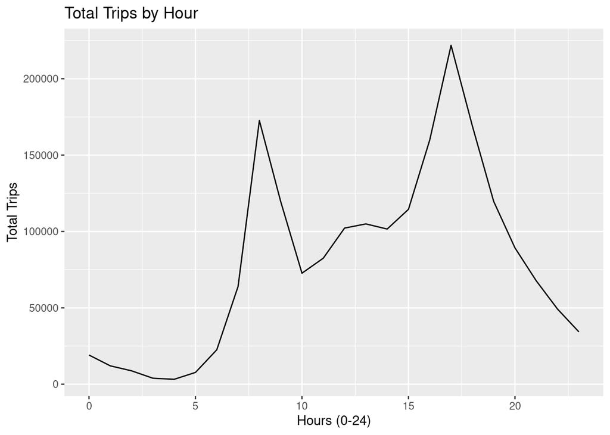

The Line Chart of Total Trips by Hour displays the total number of trips taken by hour of day for the bikeshare data in 2018. The x-axis represents the hour of the day in a 24-hour format, while the y-axis represents the total number of trips taken during that hour.

## 6.2 Stacked bar plot of trip volume by user type and month

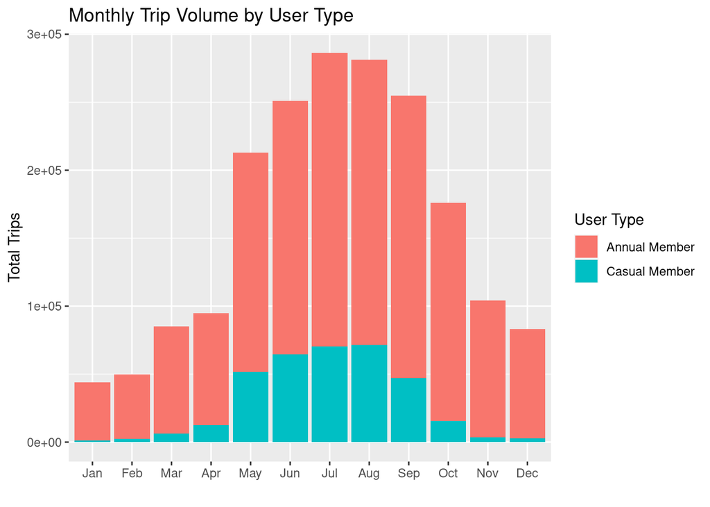

From this plot, we can see that the number of trips taken by Annual Members is consistently higher than the number of trips taken by Casual Members throughout the year. We can also observe that the number of trips taken by both user types peaks in the summer months (June to August) and declines during the winter months (December to February). This suggests that the bikeshare program is more popular during the warmer months of the year.

Overall, this plot provides an overview of the distribution of trips by user type over the months, which can help stakeholders make informed decisions about their marketing strategies and resource allocation.

## 6.3 Heatmap of trips by day of the week

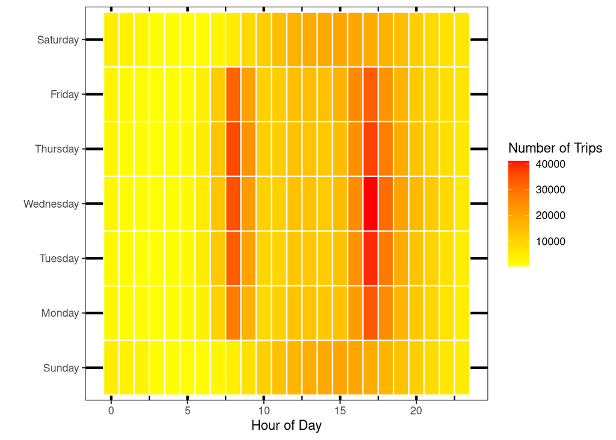

This heatmap represents the trend of the number of bike trips taken on each day of the week and at each hour of the day. The x-axis of the heatmap represents the hour of the day, while the y-axis represents the day of the week. The cells of the heatmap are colored according to the number of bike trips that occurred at each hour of the day on each day of the week. The color scale ranges from yellow (indicating low trip volumes) to red (indicating high trip volumes).

From the Heatmap, we can observe that the bike usage is highest during the weekdays, particularly on Tuesday, Wednesday, and Thursday. During these weekdays, the highest usage hours are the morning commute hours from 7-9 am and evening hours from 4-6 pm. On weekends, the usage of bikes is relatively lower than weekdays, and there is a slightly different pattern in bike usage. Bike usage is highest during the afternoon hours, particularly from 12 pm to 4 pm on both Saturday and Sunday.

Overall, this heatmap provides an insight into the bike usage pattern during different times of the week, which can help the bikeshare company to plan its resources and services accordingly.

## 6.4 Line plot of trip volume over time

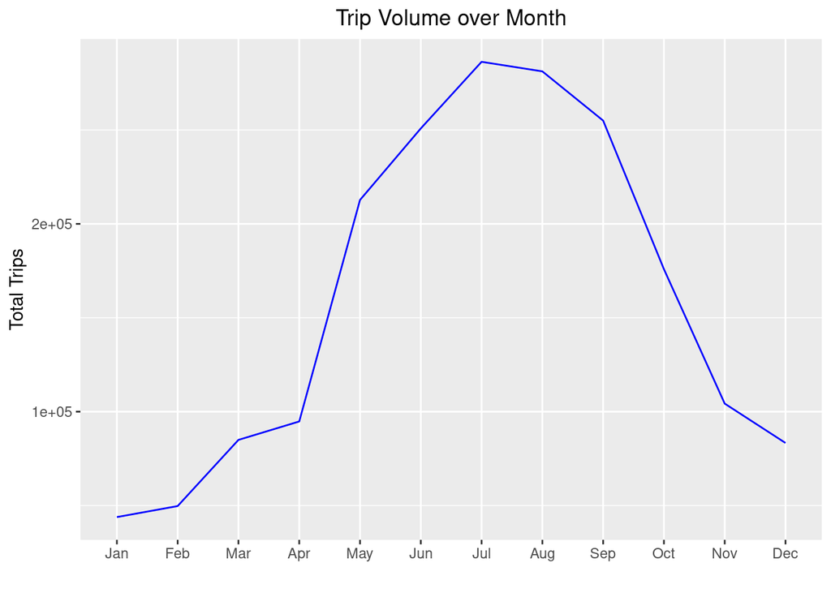

This line chart shows the total number of trips taken each month over the course of the year 2018, based on the data in the “bikeshare_data” dataset. The x-axis represents the months of the year, and the y-axis represents the total number of trips taken. Each point on the line represents the total number of trips taken in a given month. The blue line connects these points to show the trend in trip volume over the year.

From the chart, we can see that the number of trips generally increased from January to July, with the highest number of trips in July, followed by a gradual decrease in the number of trips from August to December. The chart also shows a dip in the number of trips in November and December, which may be due to seasonal factors such as colder weather. Overall, the chart provides an overview of the trend in trip volume over the course of the year 2018.

# 7. Hypothesis Testing

## Trip duration Between Trips taken on weekdays versus weekends.

We would like to determine if there is a significant difference in trip duration between trips taken on weekdays versus weekends.

**Hypothesis:**

- $H_0$: **The average trip duration on weekdays ($\mu_d$) is equal to the average trip duration on weekend** ($\mu_e$), i.e., $\mu_d=\mu_e$
- $H_1$: **The average trip duration on weekdays ($\mu_d$) is not equal to the average trip duration on weekend** ($\mu_e$), i.e., $\mu_d\neq\mu_e$

To test this hypothesis, we can use a two-sample t-test to compare the mean trip duration of weekday trips with the mean trip duration of weekend trips. We can split the data into two groups: weekday trips (Monday to Friday) and weekend trips (Saturday and Sunday).

We can then calculate the p-value associated with the t-statistic, which is the probability of observing a t-value as extreme or more extreme than the one calculated, assuming the null hypothesis is true. If the p-value is less than our significance level (typically 0.05), we can reject the null hypothesis and conclude that there is a significant difference in trip duration between weekday and weekend trips.

We can also calculate a confidence interval for the difference between the means to estimate the range of values in which the true difference between the means is likely to fall.

Overall, this hypothesis testing approach allows us to determine whether there is a statistically significant difference in trip duration between trips taken on weekdays versus weekends, and provides us with an estimate of the magnitude of this difference.

```
##
##  Welch Two Sample t-test
##
## data:  weekdays$trip_duration_seconds and weekends$trip_duration_seconds
## t = -112.86, df = 579131, p-value < 2.2e-16
## alternative hypothesis: true difference in means is not equal to 0
## 95 percent confidence interval:
##  -383.8696 -370.7647
## sample estimates:
## mean of x mean of y
##  873.7795 1251.0967
```

**The Welch Two Sample t-test shows a significant difference between the mean trip durations of weekdays and weekends. The p-value (2.2e-16) is less than the significance level of 0.05, indicating strong evidence against the null hypothesis of no difference. The confidence interval (-383.8696, -370.7647) also does not include 0, further supporting the conclusion that there is a significant difference between the two groups. Therefore, we can conclude that there is a significant difference in trip duration between trips taken on weekdays versus weekends. Specifically, the mean trip duration on weekends (1251.0967 seconds) is longer than that on weekdays (873.7795 seconds).**

# 8. Bootstrapping

## Estimating the average trip duration for casual members

We could use bootstrapping to estimate the sampling distribution of the mean and compute a confidence interval.

```
## Mean trip duration for casual members: 2032.496
```

```
## 95% confidence interval: (  2022.838 - 2042.171  )
```

**Based on the result, the mean trip duration for casual members is 2032.496 seconds. The 95% confidence interval is (2022.838 - 2042.171) seconds. This means that we are 95% confident that the true mean trip duration for casual members falls within this range.**

# 9. Non-Linear Regression Analysis

## Analyzing the relationship between the number of trips and hour of the day.

In this case, we would treat the hour of the day as a continuous variable and fit a non-linear regression model with the number of trips as the dependent variable and the hour of the day as the independent variable. The resulting model would give us information on the direction and strength of the relationship between the hour of the day and the number of trips.

```
##
## Call:
## lm(formula = num_trips ~ poly(trip_start_hour, 3, raw = TRUE),
##     data = trips_by_hour)
##
## Residuals:
##    Min     1Q Median     3Q    Max
## -38269 -21133  -9337   9561 103476
##
## Coefficients:
##                                       Estimate Std. Error t value Pr(>|t|)
## (Intercept)                           11345.41   25688.88   0.442  0.66348
## poly(trip_start_hour, 3, raw = TRUE)1 -5051.71    9882.68  -0.511  0.61483
## poly(trip_start_hour, 3, raw = TRUE)2  2225.45    1011.04   2.201  0.03964 *
## poly(trip_start_hour, 3, raw = TRUE)3   -86.35      28.87  -2.991  0.00721 **
## ---
## Signif. codes:  0 '***' 0.001 '**' 0.01 '*' 0.05 '.' 0.1 ' ' 1
##
## Residual standard error: 36500 on 20 degrees of freedom
## Multiple R-squared:  0.6909, Adjusted R-squared:  0.6445
## F-statistic:  14.9 on 3 and 20 DF,  p-value: 2.501e-05
```

## Explanation

The non-linear regression model suggests that there is a significant relationship between the number of bike trips and the hour of the day, and that this relationship is best explained by a third-order polynomial function. **The coefficient of determination (R-squared) of 0.69 indicates that the model explains 69% of the variation in the data.** The p-values for the coefficients of the quadratic and cubic terms are both significant, suggesting that the non-linear terms are needed to better explain the relationship between the number of bike trips and the hour of the day. However, the p-value for the coefficient of the linear term is not significant, suggesting that there may not be a significant linear relationship between the number of bike trips and the hour of the day.

## Intrepreting Regression Parameter

The regression parameters in this case refer to the coefficients of the independent variables in the multiple regression equation.

For this non-linear regression model, we have the following coefficients:

Overall, this suggests that there is a non-linear relationship between the hour of the day and the number of trips taken, and this relationship is well captured by the polynomial regression model.

## Plotting the Result

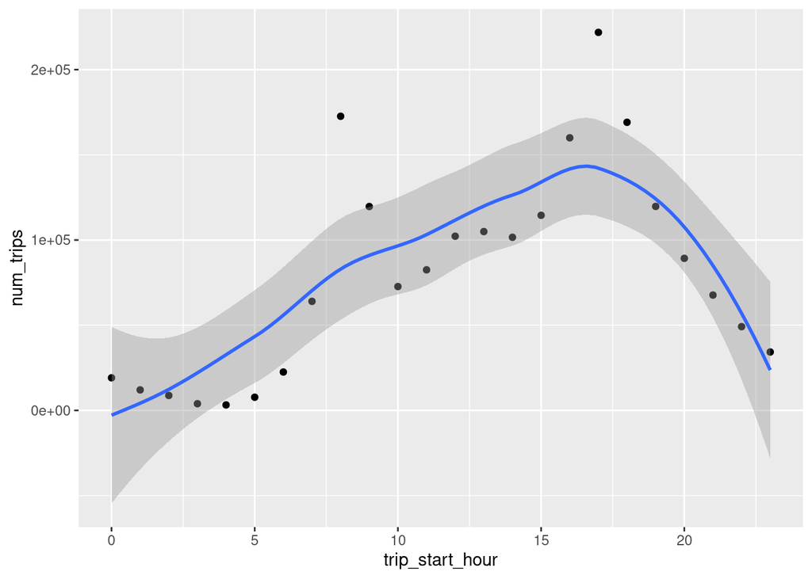

# 10. Cross Validation

## Analyzing between Trip Duration (in hour) and hour of the day

In this case, we can use cross-validation to analyze the relationship between trip duration and hour of the day in the bikeshare data.

The idea behind this approach is to split the dataset into two parts, with one part used to train the model and the other part used to validate it. We can then measure the accuracy of the model on the validation set and adjust the model as needed to improve its performance.

To use cross-validation to analyze the relationship between trip duration (in hour) and hour of the day, we would start by splitting the dataset into a training set and a validation set. We could then use **Non-linear regression** to build a model that predicts trip duration based on the hour of the day, using the training set. Once we have built the model, we would use the validation set to evaluate its performance.

Our approach is k-fold cross-validation, where the dataset is divided into k equally-sized subsets. We then train the model on k-1 of the subsets and use the remaining subset for validation. We repeat this process k times, so that each subset is used for validation once.

```
## The Average MSE is: 0.002516312
```

## Conclusion

The average MSE of 0.002516312 is quite small, which suggests that the non-linear regression model is fitting the data quite well. This means that there is likely a relationship between the hour of the day and the average trip duration (in hour), and that this relationship can be captured by the non-linear regression model.

## Plotting the Result

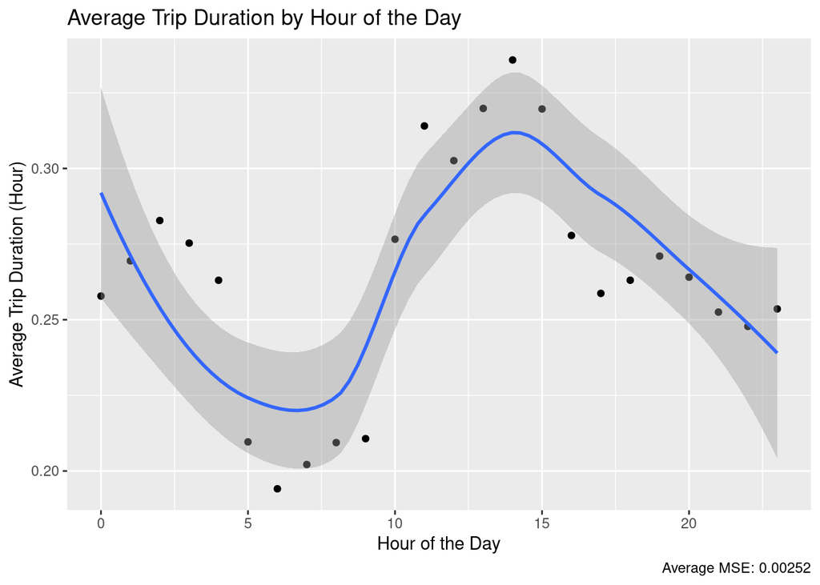

# 11. Summary of Research

Overall, the report provides insights into the usage patterns and behavior of users of the bikeshare service, which could help inform decisions about bike station placement, bike fleet size, pricing plans, and incentives to encourage more usage.